# About the Project - Python

The objective of this project is to forecast customer churn by utilizing a dataset that contains more than 20 features that have the potential to impact retention. For Python analysis, two models are chosen: Support Vector Machine (SVM) and Logistic Regression.

Binary classification tasks are well-suited to Logistic Regression, which provides high interpretability, enabling businesses to comprehend the extent to which individual features contribute to attrition risk. By contrast, SVM is a more intricate algorithm that may not offer the same level of transparency, but it frequently provides superior predictive performance, particularly in situations involving non-linear relationships and imbalanced data.

The project offers a balanced approach by integrating both an interpretable model and a more powerful, less interpretable one. This approach provides actionable insights through Logistic Regression and potentially higher accuracy and recall through SVM. This dual-model strategy provides businesses with adaptable options that are contingent upon their priorities, whether it be the optimization of predictive effectiveness or the comprehension of consumer behavior.

The primary objective is to enhance the model's capacity to accurately identify consumers who are at risk of churn. In a business setting, false positives (predicting churn when the customer would remain) are generally less expensive, as proactive retention efforts may still strengthen customer loyalty. Nevertheless, false negatives (the failure to identify a consumer who will churn) can lead to missed opportunities for intervention and lost revenue. Consequently, the model is assessed with a focus on recall for the attrition class to guarantee that retention strategies are effectively identified among at-risk customers.

# Importing the Churn Dataset

```python
!ls
```

```
Data Analytics Project Prompt.docx
FinalProject.R
FinalProject_Python.ipynb
FinalProject_R.ipynb
FinalProject_RandomForest.ipynb
Peer Review Feedback Form - Analytical Projects.pdf
Preprocessed_TelCo.csv
TelCo.csv
~$ta Analytics Project Prompt.docx
```

```python
import pandas as pd
import numpy as np
from matplotlib import pyplot as plt
import seaborn as sns
pd.set_option('display.max_colwidth', 500)
pd.set_option('display.max_columns', None)
```

```python
df = pd.read_csv("TelCo.csv")
```

```python
df.shape
```

```
(7043, 21)
```

```python
df.head()
```

|  | customerID | gender | SeniorCitizen | Partner | Dependents | tenure | PhoneService | MultipleLines | InternetService | OnlineSecurity | OnlineBackup | DeviceProtection | TechSupport | StreamingTV | StreamingMovies | Contract | PaperlessBilling | PaymentMethod | MonthlyCharges | TotalCharges | Churn |
| --- | --- | --- | --- | --- | --- | --- | --- | --- | --- | --- | --- | --- | --- | --- | --- | --- | --- | --- | --- | --- | --- |
| 0 | 7590-VHVEG | Female | 0 | Yes | No | 1 | No | No phone service | DSL | No | Yes | No | No | No | No | Month-to-month | Yes | Electronic check | 29.85 | 29.85 | No |
| 1 | 5575-GNVDE | Male | 0 | No | No | 34 | Yes | No | DSL | Yes | No | Yes | No | No | No | One year | No | Mailed check | 56.95 | 1889.5 | No |
| 2 | 3668-QPYBK | Male | 0 | No | No | 2 | Yes | No | DSL | Yes | Yes | No | No | No | No | Month-to-month | Yes | Mailed check | 53.85 | 108.15 | Yes |
| 3 | 7795-CFOCW | Male | 0 | No | No | 45 | No | No phone service | DSL | Yes | No | Yes | Yes | No | No | One year | No | Bank transfer (automatic) | 42.30 | 1840.75 | No |
| 4 | 9237-HQITU | Female | 0 | No | No | 2 | Yes | No | Fiber optic | No | No | No | No | No | No | Month-to-month | Yes | Electronic check | 70.70 | 151.65 | Yes |

# Data Preproccesing

### Searching for Duplicate Data

```python
df.index.is_unique
```

```
True
```

Because the output is True, it tells us that each row is unique and no duplicates exist in the data that would need to be removed.

### Searching for Missing Data

The code below searches through the dataframe for columns containing an empty string or NA values. According to the output, the only missing values were in the TotalCharges column. To allow for future explanations, these rows will not be removed.

```python
# Search for NA or missing strings in dataset

col_with_NA = []

for col in df:
    if df[col].isnull().any() or df[col].eq(' ').any():
        col_with_NA.append(col)

print(col_with_NA)
```

```
['TotalCharges']
```

### One-Hot Encoding Features

One-hot encoding turns multi-value features into binary features. For example, ['MultipleLines'] has 3 possible values: 'Yes,' 'No,' and 'No Phone Service.' To make these features binary, each possible value must become its own binary column such that column ['MultipleLines_Yes'] is binary to whether the customer said yes (1) to having multiple lines or no phone service/no (0).

To prevent perfect multicollinearity, which refers to the highly related dummy variables, one of each of the dummy variables will be removed. These features are highly related because if InternetService_FiberOptic and InternetService_No are both 0 values, then InternetService_DSL is highly predictable and causes issues for the logistic regression model and the SVM. These dummy features that are going to be omitted will coincide with those from the R Project, and they will only be omitted from the model, not dropped from the dataset.

Additionally, there is high multicollinearity with PhoneService and MultipleLines_No Phone Service. That being said, PhoneService will be omitted for easier implementation in both this Python project and the R project.

### Removed Features:

- InternetService_DSL
- Contract_Month-to-month
- MultipleLines_No
- PaymentMethod_BankTransfer
- PhoneService

```python
df.info()
```

```
<class 'pandas.core.frame.DataFrame'>
RangeIndex: 7043 entries, 0 to 7042
Data columns (total 21 columns):
 #   Column            Non-Null Count  Dtype
---  ------            --------------  -----
 0   customerID        7043 non-null   object
 1   gender            7043 non-null   object
 2   SeniorCitizen     7043 non-null   int64
 3   Partner           7043 non-null   object
 4   Dependents        7043 non-null   object
 5   tenure            7043 non-null   int64
 6   PhoneService      7043 non-null   object
 7   MultipleLines     7043 non-null   object
 8   InternetService   7043 non-null   object
 9   OnlineSecurity    7043 non-null   object
 10  OnlineBackup      7043 non-null   object
 11  DeviceProtection  7043 non-null   object
 12  TechSupport       7043 non-null   object
 13  StreamingTV       7043 non-null   object
 14  StreamingMovies   7043 non-null   object
 15  Contract          7043 non-null   object
 16  PaperlessBilling  7043 non-null   object
 17  PaymentMethod     7043 non-null   object
 18  MonthlyCharges    7043 non-null   float64
 19  TotalCharges      7043 non-null   object
 20  Churn             7043 non-null   object
dtypes: float64(1), int64(2), object(18)
memory usage: 1.1+ MB
```

```python
df.shape
```

```
(7043, 21)
```

```python
# create a list of columns that are data type 'object' and have greater than 2 values to be one-hot encoded
# used 20 as a unique value counts threshold to determine if any object types are wrong and should be considered numeric
    # this Prevents them from being one-hot encoded on accident. 20 is a good number as it is not too large by iteself but if needed to be one-hot encoded it would mostly cause problems for our model.
one_hot_encoding_cols = []
col_to_binary = []

for x in df:
    if len(df[x].value_counts()) > 2 and len(df[x].value_counts()) < 20 and df[x].dtype == 'object':
        one_hot_encoding_cols.append(x)
    elif len(df[x].value_counts()) == 2 and df[x].dtype == 'object':
        col_to_binary.append(x)

print("One-hot encoding columns: ", one_hot_encoding_cols)
print("Columns to be transformed into binary: ", col_to_binary)
```

```
One-hot encoding columns:  ['MultipleLines', 'InternetService', 'OnlineSecurity', 'OnlineBackup', 'DeviceProtection', 'TechSupport', 'StreamingTV', 'StreamingMovies', 'Contract', 'PaymentMethod']
Columns to be transformed into binary:  ['gender', 'Partner', 'Dependents', 'PhoneService', 'PaperlessBilling', 'Churn']
```

(Above) It appears that there are ten columns in need of one-hot encoding, and after seeing each of their value counts, maybe they can be further reduced to prevent too high a dataset dimension.

```python
for x in one_hot_encoding_cols:
    print(df[x].value_counts())
    print("----"*15)
```

```
MultipleLines
No                  3390
Yes                 2971
No phone service     682
Name: count, dtype: int64
------------------------------------------------------------
InternetService
Fiber optic    3096
DSL            2421
No             1526
Name: count, dtype: int64
------------------------------------------------------------
OnlineSecurity
No                     3498
Yes                    2019
No internet service    1526
Name: count, dtype: int64
------------------------------------------------------------
OnlineBackup
No                     3088
Yes                    2429
No internet service    1526
Name: count, dtype: int64
------------------------------------------------------------
DeviceProtection
No                     3095
Yes                    2422
No internet service    1526
Name: count, dtype: int64
------------------------------------------------------------
TechSupport
No                     3473
Yes                    2044
No internet service    1526
Name: count, dtype: int64
------------------------------------------------------------
StreamingTV
No                     2810
Yes                    2707
No internet service    1526
Name: count, dtype: int64
------------------------------------------------------------
StreamingMovies
No                     2785
Yes                    2732
No internet service    1526
Name: count, dtype: int64
------------------------------------------------------------
Contract
Month-to-month    3875
Two year          1695
One year          1473
Name: count, dtype: int64
------------------------------------------------------------
PaymentMethod
Electronic check             2365
Mailed check                 1612
Bank transfer (automatic)    1544
Credit card (automatic)      1522
Name: count, dtype: int64
------------------------------------------------------------
```

Above, several features indicate either "No Phone Service" or "No Internet Service." For the sake of reducing multicollinearity between features, these values are going to be transformed into "No" in the Changing Binary String Values into Binary Integer Values section of the project below.

```python
one_hot_encoding_cols
```

```
['MultipleLines',
 'InternetService',
 'OnlineSecurity',
 'OnlineBackup',
 'DeviceProtection',
 'TechSupport',
 'StreamingTV',
 'StreamingMovies',
 'Contract',
 'PaymentMethod']
```

```python
# for the columns that have these phrases they will be extracted from one_hot_encoding_cols
for i in one_hot_encoding_cols:
    if ("No internet service" in df[i].values) or ("No phone service" in df[i].values):
        col_to_binary.append(i)

print(col_to_binary)
```

```
['gender', 'Partner', 'Dependents', 'PhoneService', 'PaperlessBilling', 'Churn', 'MultipleLines', 'OnlineSecurity', 'OnlineBackup', 'DeviceProtection', 'TechSupport', 'StreamingTV', 'StreamingMovies']
```

```python
one_hot_encoding_cols = list(set(one_hot_encoding_cols) - set(col_to_binary))
```

```python
one_hot_encoding_cols
```

```
['PaymentMethod', 'InternetService', 'Contract']
```

```python
dummies_all = pd.get_dummies(df, columns = one_hot_encoding_cols, drop_first = False, dtype = int)
df = pd.get_dummies(df, columns = one_hot_encoding_cols, drop_first = True, dtype = int)

# this will determine our intercept features when running the models
intercept_features = set(dummies_all.columns) - set(df.columns)
print(intercept_features)
```

```
{'PaymentMethod_Bank transfer (automatic)', 'InternetService_DSL', 'Contract_Month-to-month'}
```

```python
df.head()
```

|  | customerID | gender | SeniorCitizen | Partner | Dependents | tenure | PhoneService | MultipleLines | OnlineSecurity | OnlineBackup | DeviceProtection | TechSupport | StreamingTV | StreamingMovies | PaperlessBilling | MonthlyCharges | TotalCharges | Churn | PaymentMethod_Credit card (automatic) | PaymentMethod_Electronic check | PaymentMethod_Mailed check | InternetService_Fiber optic | InternetService_No | Contract_One year | Contract_Two year |
| --- | --- | --- | --- | --- | --- | --- | --- | --- | --- | --- | --- | --- | --- | --- | --- | --- | --- | --- | --- | --- | --- | --- | --- | --- | --- |
| 0 | 7590-VHVEG | Female | 0 | Yes | No | 1 | No | No phone service | No | Yes | No | No | No | No | Yes | 29.85 | 29.85 | No | 0 | 1 | 0 | 0 | 0 | 0 | 0 |
| 1 | 5575-GNVDE | Male | 0 | No | No | 34 | Yes | No | Yes | No | Yes | No | No | No | No | 56.95 | 1889.5 | No | 0 | 0 | 1 | 0 | 0 | 1 | 0 |
| 2 | 3668-QPYBK | Male | 0 | No | No | 2 | Yes | No | Yes | Yes | No | No | No | No | Yes | 53.85 | 108.15 | Yes | 0 | 0 | 1 | 0 | 0 | 0 | 0 |
| 3 | 7795-CFOCW | Male | 0 | No | No | 45 | No | No phone service | Yes | No | Yes | Yes | No | No | No | 42.30 | 1840.75 | No | 0 | 0 | 0 | 0 | 0 | 1 | 0 |
| 4 | 9237-HQITU | Female | 0 | No | No | 2 | Yes | No | No | No | No | No | No | No | Yes | 70.70 | 151.65 | Yes | 0 | 1 | 0 | 1 | 0 | 0 | 0 |

### Changing Binary String Values into Binary Integer Values

It is necessary for the models that binary string features (Yes and No) are turned into binary integer features (0 and 1), where Yes = 1 and No = 0. This is also done for gender, where male = 1 and female = 0, but because gender is not a yes/no binary, it needs to be removed from the col_to_binary group for manual transformation.

```python
df.head()
```

|  | customerID | gender | SeniorCitizen | Partner | Dependents | tenure | PhoneService | MultipleLines | OnlineSecurity | OnlineBackup | DeviceProtection | TechSupport | StreamingTV | StreamingMovies | PaperlessBilling | MonthlyCharges | TotalCharges | Churn | PaymentMethod_Credit card (automatic) | PaymentMethod_Electronic check | PaymentMethod_Mailed check | InternetService_Fiber optic | InternetService_No | Contract_One year | Contract_Two year |
| --- | --- | --- | --- | --- | --- | --- | --- | --- | --- | --- | --- | --- | --- | --- | --- | --- | --- | --- | --- | --- | --- | --- | --- | --- | --- |
| 0 | 7590-VHVEG | Female | 0 | Yes | No | 1 | No | No phone service | No | Yes | No | No | No | No | Yes | 29.85 | 29.85 | No | 0 | 1 | 0 | 0 | 0 | 0 | 0 |
| 1 | 5575-GNVDE | Male | 0 | No | No | 34 | Yes | No | Yes | No | Yes | No | No | No | No | 56.95 | 1889.5 | No | 0 | 0 | 1 | 0 | 0 | 1 | 0 |
| 2 | 3668-QPYBK | Male | 0 | No | No | 2 | Yes | No | Yes | Yes | No | No | No | No | Yes | 53.85 | 108.15 | Yes | 0 | 0 | 1 | 0 | 0 | 0 | 0 |
| 3 | 7795-CFOCW | Male | 0 | No | No | 45 | No | No phone service | Yes | No | Yes | Yes | No | No | No | 42.30 | 1840.75 | No | 0 | 0 | 0 | 0 | 0 | 1 | 0 |
| 4 | 9237-HQITU | Female | 0 | No | No | 2 | Yes | No | No | No | No | No | No | No | Yes | 70.70 | 151.65 | Yes | 0 | 1 | 0 | 1 | 0 | 0 | 0 |

The features in need of binary conversion include:

```python
col_to_binary
```

```
['gender',
 'Partner',
 'Dependents',
 'PhoneService',
 'PaperlessBilling',
 'Churn',
 'MultipleLines',
 'OnlineSecurity',
 'OnlineBackup',
 'DeviceProtection',
 'TechSupport',
 'StreamingTV',
 'StreamingMovies']
```

```python
col_to_binary.remove('gender')
```

```python
# for all the columns in col to binary if value is 'yes' the binary results will be 1, anything else (no, no service, etc.) will be 0
for col in col_to_binary:
    df[col] =[1 if value == "Yes" else 0 for value in df[col]]
```

```python
df["gender"] =[1 if value == "Male" else 0 for value in df["gender"]]
```

```python
df.head(1)
```

|  | customerID | gender | SeniorCitizen | Partner | Dependents | tenure | PhoneService | MultipleLines | OnlineSecurity | OnlineBackup | DeviceProtection | TechSupport | StreamingTV | StreamingMovies | PaperlessBilling | MonthlyCharges | TotalCharges | Churn | PaymentMethod_Credit card (automatic) | PaymentMethod_Electronic check | PaymentMethod_Mailed check | InternetService_Fiber optic | InternetService_No | Contract_One year | Contract_Two year |
| --- | --- | --- | --- | --- | --- | --- | --- | --- | --- | --- | --- | --- | --- | --- | --- | --- | --- | --- | --- | --- | --- | --- | --- | --- | --- |
| 0 | 7590-VHVEG | 0 | 0 | 1 | 0 | 1 | 0 | 0 | 0 | 1 | 0 | 0 | 0 | 0 | 1 | 29.85 | 29.85 | 0 | 0 | 1 | 0 | 0 | 0 | 0 | 0 |

As seen above, every feature that was an object data type with two variables, 'Yes' or 'No', has now been converted into integer data types, 1 and 0, respectively.

### Creating Binary Values for Continuous Data

To turn continuous variables into binary values 1 and 0, the data will be split into above or equal to the median (1) or below the median (0)

```python
# identifying the features in need of transformation
cont_to_binary = []

for x in df:
    if len(df[x].value_counts()) > 2 and (df[x].dtype == 'int64' or df[x].dtype == 'float64'):
        cont_to_binary.append(x)
```

```python
cont_to_binary
```

```
['tenure', 'MonthlyCharges']
```

The code below indicates that there are no outliers for the tenure class in the dataset

```python
# Determine if there are outliers in the continous features to be made binary
for wrd in cont_to_binary:
    q25,q50,q75 = np.percentile(df[wrd],[25,50,75])
    iqr = q75 - q25
    minn = q25 - 1.5*(iqr)
    maxx = q75 + 1.5*(iqr)
    for x in df[wrd]:
        if x > maxx:
            outcome = "Outlier present"
        elif x < minn:
            outcome = "Outlier present"
        else:
            outcome = "No outlier present"
    print(outcome, "for:", wrd)
```

```
No outlier present for: tenure
No outlier present for: MonthlyCharges
```

No outliers are present for either continuous value; this is reiterated in the boxplots below. Outliers would appear as circles in the graph above or below the expected range of the data.

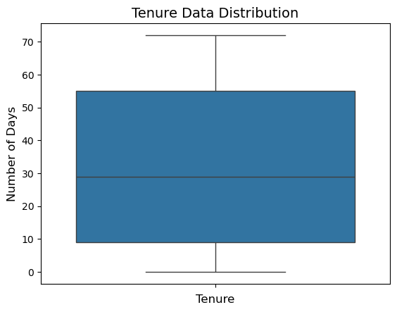

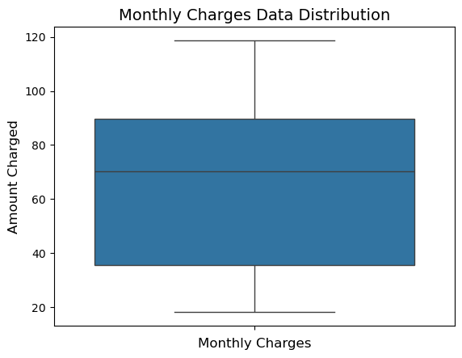

```python
# plotting loop that displays the continous features made binary with separate if statements for graph and axes titles
for wrd in cont_to_binary:
    sns.boxplot(df[wrd])
    # Add titles and labels
    if wrd == "tenure":
        plt.title("Tenure Data Distribution", fontsize=14)
        plt.xlabel("Tenure", fontsize=12)
        plt.ylabel("Number of Days", fontsize=12)
    elif wrd == "MonthlyCharges":
        plt.title("Monthly Charges Data Distribution", fontsize=14)
        plt.xlabel("Monthly Charges", fontsize=12)
        plt.ylabel("Amount Charged", fontsize=12)

    # Show the plot
    plt.show()
```

The boxplots confirms that there are no outliers in the tenure column. Outliers would appear as circles in the graph above or below the expected range of the data. With that being said, the data can be made binary.

```python
# create binary values for continous features, in which any values greater than or equal to the median = 1 and all else = 0
for wrd in cont_to_binary:
    df[wrd] = [1 if value >= df[wrd].median() else 0 for value in df[wrd]]
```

### 'TotalCharges' Column Reasoning

'TotalCharges' is more or less derived from a combination of 'tenure' and 'MonthlyCharges'. Because of this, including 'TotalCharges' would make the data redundant and can lead to interpretive issues and potential overfitting.

That being said, 'TotalCharges' column is going to not being used in the models.

### Predicted Feature Column: Churn

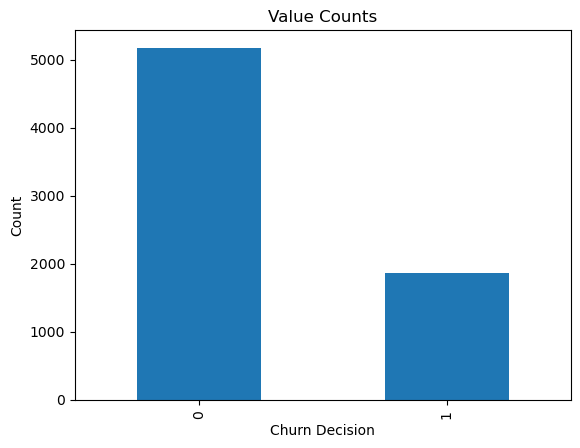

```python
df['Churn'].value_counts().plot(kind='bar')
plt.xlabel('Churn Decision')
plt.ylabel('Count')
plt.title('Value Counts')
plt.show()
```

```python
df['Churn'].value_counts()
```

```
Churn
0    5174
1    1869
Name: count, dtype: int64
```

Our dataset suggests that there are a large number of instances where customers did not churn to those who did. While this is normal for a real-world scenario, it may have an effect on how well our model can learn to correctly label someone who is going to churn.

### Troubleshooting Data

After initially running this model, there were issues with some features being multicollinear. In a model where there is no multicollinearity, values in the coefficient table would all contain metrics; however, issues when there are missing values in the table indicate the presence of multicollinearity for those features. To determine which of these features is causing the lack of metrics in the table, a variance inflation factor (VIF) can be run to score each dataset feature. A feature with a high VIF value (VIF > 10) indicates a large similarity/multicollinearity with another feature.

OpenAI. (2025, August 4). Conversation with ChatGPT about logistic regression, standard error, and multicollinearity. ChatGPT (Version 4.0) [Large language model]. https://chat.openai.com/

# Model Setup

```python
predicted_class = df['Churn']
```

```python
df.info()
```

```
<class 'pandas.core.frame.DataFrame'>
RangeIndex: 7043 entries, 0 to 7042
Data columns (total 25 columns):
 #   Column                                 Non-Null Count  Dtype
---  ------                                 --------------  -----
 0   customerID                             7043 non-null   object
 1   gender                                 7043 non-null   int64
 2   SeniorCitizen                          7043 non-null   int64
 3   Partner                                7043 non-null   int64
 4   Dependents                             7043 non-null   int64
 5   tenure                                 7043 non-null   int64
 6   PhoneService                           7043 non-null   int64
 7   MultipleLines                          7043 non-null   int64
 8   OnlineSecurity                         7043 non-null   int64
 9   OnlineBackup                           7043 non-null   int64
```

[output cut: 17 more lines]

```python
# determining which columns need to be removed from the model by using the class of the data, whether it is the predicted features, or whether it should be manually removed ('PhoneService')
col_to_remove = []

for col in df.columns:
    if df[col].dtype == 'object' or col == predicted_class.name or col == 'PhoneService':
        col_to_remove.append(col)

print(col_to_remove)
```

```
['customerID', 'PhoneService', 'TotalCharges', 'Churn']
```

```python
#removing the columns from the above for loop from the columns that will be used as independent variables for the model.
col_to_model = list(set(df.columns) - set(col_to_remove))
print(col_to_model)
```

[output not shown]

```python
X = df[col_to_model]
y = df[predicted_class.name]
```

Because our dataset is now entirely binary there is no need to normalize or scale our data.

```python
from sklearn.model_selection import train_test_split
X_train, X_test, y_train, y_test = train_test_split(X, y, test_size=0.2, random_state=42)
```

# Logistic Regression

The logistic regression model is a simple classification that looks specifically at binary values (1 and 0). It models the logrithmic odds probability of the target value equaling 1, or in this case if customer will churn.

```python
from sklearn.linear_model import LogisticRegression
```

```python
# using the fit_intercept parameter will allow an intercept feature to help make up the lost multiclass features.
log_model = LogisticRegression(fit_intercept = True)
```

```python
log_model.fit(X_train, np.ravel(y_train))
```

```
LogisticRegression()
```

```python
y_pred = log_model.predict(X_test)
```

```python
from sklearn import metrics
cnf_matrix = metrics.confusion_matrix(y_test, y_pred)
cnf_matrix
```

```
array([[934, 102],
       [161, 212]])
```

```python
from sklearn.metrics import classification_report
target_names = ['Customer Did Not Churn', 'Churner']
print(classification_report(y_test, y_pred, target_names=target_names))
```

```
                        precision    recall  f1-score   support

Customer Did Not Churn       0.85      0.90      0.88      1036
               Churner       0.68      0.57      0.62       373

              accuracy                           0.81      1409
             macro avg       0.76      0.73      0.75      1409
          weighted avg       0.81      0.81      0.81      1409
```

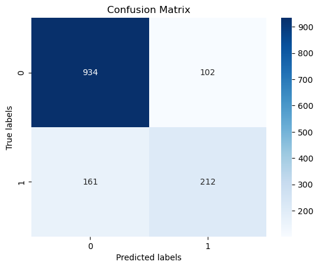

```python
sns.heatmap(cnf_matrix, annot=True, fmt='g', cmap='Blues')
plt.xlabel('Predicted labels')
plt.ylabel('True labels')
plt.title('Confusion Matrix')
plt.show()
```

The heatmap visualization reveals that the Logistic Regression model correctly identified 212 customers who churned, while incorrectly labeling 102 customers as churners. This level of false positives is acceptable in the business context, as previously discussed—it's generally preferable to mistakenly flag a customer as likely to churn than to miss one who actually does. On the other hand, the model correctly classified 934 customers as non-churners but failed to identify 161 actual churners, misclassifying them as non-churners. This group represents a critical loss, as these customers were not targeted for retention efforts and ultimately left the service.

Below, the metrics for how each feature affects churn are identified.

In order to understand the effect each feature is having on churn for customers, ChatGPT was used to help provide code that would acquire the Coefficient score, Odds Ratio, and the Effect (%). This source was also used to create the Error (%) graph that shows the features in descending order of the absolute value of Effect(%).

- OpenAI. (2025, July 24). Response to a query about logistic regression odds ratio visualization and interpretability. ChatGPT (Version GPT-4o) [Large language model]. https://chat.openai.com/

```python
import statsmodels.api as sm
# Add intercept manually to X_train
X_train_const = sm.add_constant(X_train)

# Fit logistic regression model
logit_model = sm.Logit(y_train, X_train_const)
result = logit_model.fit()
```

```
Optimization terminated successfully.
         Current function value: 0.428882
         Iterations 8
```

```python
# Get coefficient summary
summary_df = result.summary2().tables[1].reset_index()
summary_df.rename(columns={'index': 'Feature', 'Coef.': 'Coefficient', 'Std.Err.': 'StdErr'}, inplace=True)
```

```python
# Calculate Odds Ratio and Effect (%)
summary_df['Odds Ratio'] = np.exp(summary_df['Coefficient'])
summary_df['Effect (%)'] = (summary_df['Odds Ratio'] - 1) * 100
```

```python
# Sort by absolute effect size
summary_df['abs_effect'] = summary_df['Effect (%)'].abs()
summary_df = summary_df.sort_values(by='abs_effect', ascending=False).drop(columns='abs_effect')

print(summary_df.to_string(index = False))
```

```
                              Feature  Coefficient   StdErr          z        P>|z|    [0.025    0.975]  Odds Ratio  Effect (%)
          InternetService_Fiber optic     0.907958 0.155658   5.833036 5.442786e-09  0.602874  1.213042    2.479255  147.925548
                    Contract_Two year    -1.930422 0.188416 -10.245539 1.239315e-24 -2.299710 -1.561134    0.145087  -85.491301
                   InternetService_No    -1.005968 0.144498  -6.961790 3.359759e-12 -1.289179 -0.722756    0.365691  -63.430942
                    Contract_One year    -0.923549 0.112910  -8.179482 2.850678e-16 -1.144849 -0.702249    0.397107  -60.289280
                               tenure    -0.782255 0.095277  -8.210330 2.205811e-16 -0.968995 -0.595516    0.457373  -54.262660
       PaymentMethod_Electronic check     0.426789 0.101761   4.194033 2.740382e-05  0.227341  0.626237    1.532330   53.232992
                                const    -0.732521 0.133046  -5.505791 3.675152e-08 -0.993285 -0.471756    0.480696  -51.930429
                       OnlineSecurity    -0.497937 0.092950  -5.357015 8.460794e-08 -0.680116 -0.315757    0.607783  -39.221651
                      StreamingMovies     0.322444 0.088309   3.651312 2.609036e-04  0.149361  0.495526    1.380497   38.049725
                     PaperlessBilling     0.304129 0.081473   3.732897 1.892898e-04  0.144446  0.463813    1.355444   35.544420
                          TechSupport    -0.373899 0.094484  -3.957278 7.580867e-05 -0.559085 -0.188714    0.688046  -31.195387
                       MonthlyCharges    -0.317061 0.166411  -1.905291 5.674223e-02 -0.643219  0.009098    0.728287  -27.171344
                          StreamingTV     0.225864 0.088540   2.550966 1.074247e-02  0.052328  0.399400    1.253405   25.340464
                         OnlineBackup    -0.246480 0.082565  -2.985296 2.833042e-03 -0.408303 -0.084656    0.781547  -21.845271
                        SeniorCitizen     0.142221 0.092532   1.536991 1.242955e-01 -0.039139  0.323580    1.152831   15.283114
                        MultipleLines     0.131417 0.086161   1.525245 1.271979e-01 -0.037456  0.300290    1.140443   14.044340
                           Dependents    -0.149505 0.098245  -1.521762 1.280687e-01 -0.342061  0.043051    0.861134  -13.886581
           PaymentMethod_Mailed check     0.128146 0.123701   1.035939 3.002307e-01 -0.114302  0.370595    1.136719   13.671918
PaymentMethod_Credit card (automatic)    -0.070761 0.124030  -0.570516 5.683279e-01 -0.313856  0.172334    0.931684   -6.831564
                              Partner    -0.061778 0.084370  -0.732229 4.640285e-01 -0.227141  0.103584    0.940091   -5.990868
                               gender    -0.061479 0.071136  -0.864252 3.874493e-01 -0.200902  0.077944    0.940373   -5.962736
                     DeviceProtection    -0.037550 0.086647  -0.433363 6.647509e-01 -0.207375  0.132276    0.963147   -3.685344
```

```python
from statsmodels.stats.outliers_influence import variance_inflation_factor

vif_data = pd.DataFrame()
vif_data['feature'] = X.columns
vif_data['VIF'] = [variance_inflation_factor(X.values, i) for i in range(len(X.columns))]
vif_data = vif_data.sort_values(by='VIF', ascending=False)

print(vif_data)
```

```
                                  feature       VIF
16                         MonthlyCharges  8.851671
8             InternetService_Fiber optic  6.166302
18                                 tenure  3.721117
7                       Contract_Two year  2.904787
6                         StreamingMovies  2.768159
4                             StreamingTV  2.756989
20                                Partner  2.743228
13                       PaperlessBilling  2.643111
12                     InternetService_No  2.474590
5                           MultipleLines  2.413581
14                       DeviceProtection  2.246289
10         PaymentMethod_Electronic check  2.173091
3                             TechSupport  2.046421
15                           OnlineBackup  2.041773
2                              Dependents  1.954100
0                       Contract_One year  1.940535
19                         OnlineSecurity  1.886482
17                                 gender  1.879682
9              PaymentMethod_Mailed check  1.746745
1   PaymentMethod_Credit card (automatic)  1.692679
11                          SeniorCitizen  1.359252
```

- The Coeffecient score is the raw value that comes out of the model for the given feature.
- The StdErr represents the standard error of the features which is a measurement of expected variation in the feature.
  - Larger Standard Error in relation to the coeff size indicates a less precise coeff, and vice versa for smaller standard error.
- The Odds Ratio explains the multiplicative change per one unit increase in the predictor/feature.
- The Effect (%) is the percent change (increase or decrease in odds) expressed by the feature to whether or not a customer will churn.

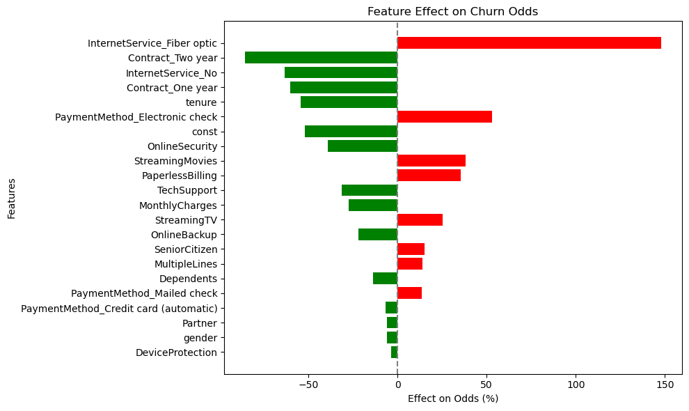

```python
plt.figure(figsize=(10, 6))
colors = ['green' if val < 0 else 'red' for val in summary_df['Effect (%)']]
bars = plt.barh(y=summary_df['Feature'],
                width=summary_df['Effect (%)'],

                color=colors)
plt.xlabel('Effect on Odds (%)')
plt.ylabel('Features')
plt.title('Feature Effect on Churn Odds')
plt.axvline(x=0, color='gray', linestyle='--')  # reference line at 0
plt.tight_layout()
plt.gca().invert_yaxis()
plt.show()
```

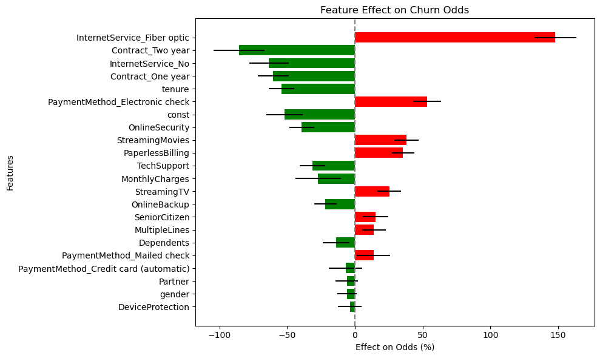

```python
# plot with standard error bars
plt.figure(figsize=(10, 6))
colors = ['green' if val < 0 else 'red' for val in summary_df['Effect (%)']]
bars = plt.barh(y=summary_df['Feature'],
                width=summary_df['Effect (%)'],
                xerr=summary_df['StdErr'] * 100,
                color=colors)
plt.xlabel('Effect on Odds (%)')
plt.ylabel('Features')
plt.title('Feature Effect on Churn Odds')
plt.axvline(x=0, color='gray', linestyle='--')  # reference line at 0
plt.tight_layout()
plt.gca().invert_yaxis()
plt.show()
```

```python
feature_effect = pd.DataFrame()
feature_effect['Feature'] = summary_df['Feature']
feature_effect['Effect (%)'] = summary_df['Effect (%)']
feature_effect.head()
```

|  | Feature | Effect (%) |
| --- | --- | --- |
| 9 | InternetService_Fiber optic | 147.925548 |
| 8 | Contract_Two year | -85.491301 |
| 13 | InternetService_No | -63.430942 |
| 1 | Contract_One year | -60.289280 |
| 19 | tenure | -54.262660 |

The above graph shows very valuable information about how features affected churn, provided by the Logistic Regression. The red bars indicate an increase in churn, while the green bars indicate a decreased percentage of churn. The top five largest effects (descending from the top) are:

(The first feature increases churn likelihood.)

1. InternetService_Fiber optic: Customers who had fiber optic internet services were 148% more likely to churn.

(The next four features reduce churn likelihood.)

2. Contract_Two year: Customers who had a two-year contract were 85% less likely to churn.
3. InternetService_No: Customers with no internet services were 63% less likely to churn.
4. Contract_One year: Customers who had a one-year contract were 60% less likely to churn.
5. tenure: Customers who stayed at the company for greater than or equal to the median were 54% less likely to churn

Although the Logistic Regression model was not incredibly strong at correctly labeling all of customers who were going to churn, it revealed important feature metrics that a business can use in customer retention strategies.

The next model, the Support Vector Machine, may be able to provide a stronger model with higher accuracy and recall.

# Support Vector Machine (SVM)

The SVM classification model works by finding the optimal hyperplane that separates the binary target values. When new data is then input into the model, it is classified based on if it falls above the hyperplane or below the hyperplane.

```python
from sklearn import svm
```

```python
model = svm.SVC(random_state=42, kernel='rbf', gamma = 'auto', probability = True)
model.fit(X_train, np.ravel(y_train))

y_pred = model.predict(X_test)
print(classification_report(y_test, y_pred, target_names=target_names))
```

```
                        precision    recall  f1-score   support

Customer Did Not Churn       0.84      0.92      0.88      1036
               Churner       0.69      0.51      0.59       373

              accuracy                           0.81      1409
             macro avg       0.76      0.71      0.73      1409
          weighted avg       0.80      0.81      0.80      1409
```

```python
model = svm.SVC(random_state=42, kernel='linear')
model.fit(X_train, np.ravel(y_train))

y_pred = model.predict(X_test)
print(classification_report(y_test, y_pred, target_names=target_names))
```

```
                        precision    recall  f1-score   support

Customer Did Not Churn       0.84      0.90      0.87      1036
               Churner       0.65      0.54      0.59       373

              accuracy                           0.80      1409
             macro avg       0.75      0.72      0.73      1409
          weighted avg       0.79      0.80      0.80      1409
```

```python
model = svm.SVC(random_state=42, kernel='poly')
model.fit(X_train, np.ravel(y_train))

y_pred = model.predict(X_test)
print(classification_report(y_test, y_pred, target_names=target_names))
```

```
                        precision    recall  f1-score   support

Customer Did Not Churn       0.83      0.92      0.87      1036
               Churner       0.69      0.49      0.57       373

              accuracy                           0.80      1409
             macro avg       0.76      0.70      0.72      1409
          weighted avg       0.79      0.80      0.79      1409
```

```python
model = svm.SVC(random_state=42, kernel='sigmoid', gamma = 'auto', probability = True)
model.fit(X_train, np.ravel(y_train))

y_pred = model.predict(X_test)
print(classification_report(y_test, y_pred, target_names=target_names))
```

```
                        precision    recall  f1-score   support

Customer Did Not Churn       0.86      0.89      0.87      1036
               Churner       0.66      0.58      0.62       373

              accuracy                           0.81      1409
             macro avg       0.76      0.74      0.75      1409
          weighted avg       0.80      0.81      0.81      1409
```

This model was the best of the four, using a sigmoid kernel, 'auto' gamma, and true probability. It had the highest recall for churners at 58% and an overall model accuracy of 81%.

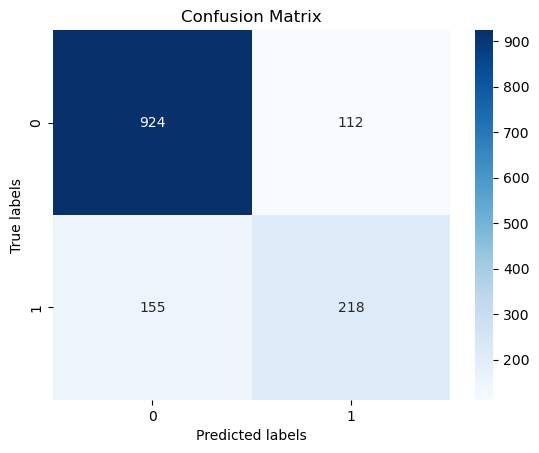

```python
sns.heatmap(metrics.confusion_matrix(y_test, y_pred), annot=True, fmt='g', cmap='Blues')
plt.xlabel('Predicted labels')
plt.ylabel('True labels')
plt.title('Confusion Matrix')
plt.show()
```

The heatmap visualization reveals that the SVM model correctly identified 218 customers who churned, while incorrectly labeling 112 customers as churners. This level of false positives is acceptable in the business context, as previously discussed—it's generally preferable to mistakenly flag a customer as likely to churn than to miss one who actually does. On the other hand, the model correctly classified 924 customers as non-churners but failed to identify 155 actual churners, misclassifying them as non-churners. This group represents a critical loss, as these customers were not targeted for retention efforts and ultimately left the service.

Although this is still a large number of lost customers, in terms of model strength, it shows that the SVM failed to identify around 6 less churning customers than the Logistic Regression Model.

# Conclusion

The Support Vector Machine (SVM) model outperformed Logistic Regression in terms of predictive performance, although only marginally. Despite its slightly inferior performance, logistic regression provided valuable insights into how various characteristics influence churn, delivering interpretability that SVM lacked.

Given this trade-off, Logistic Regression may be a more realistic option for business applications where understanding churn reasons is just as critical as forecast accuracy. Its transparency allows for data-driven decision-making and tailored retention measures, making it a great contender despite a slight performance gap compared to SVM.